# Text Analysis Notebook

Lars Hinrichs

14-Oct-2020

```r
if (!require(pacman)) install.packages("pacman")
library(pacman)
p_load(rio, tidyverse, tidytext, knitr, flextable,
       kableExtra,
       textreadr, gutenbergr, janitor)
opts_chunk$set(cache = TRUE)
```

## Digital text analysis: a look at the toolbox

Having read [the NYT piece](https://www.nytimes.com/2020/10/12/style/self-care/social-media-.html) about social media text analysis, and perhaps from your own life in this digital world of ours!!, you have at least head about some of the methods that a “computational sociolinguist” or a “digital humanist” might apply to text.

### Sentiment analysis

#### “Positive” versus “negative” words

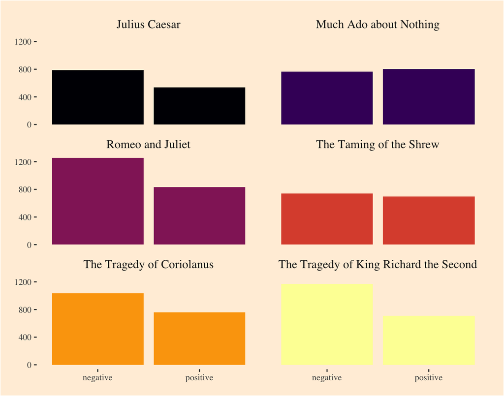

Sentiment analysis: n pos v. n neg per text.

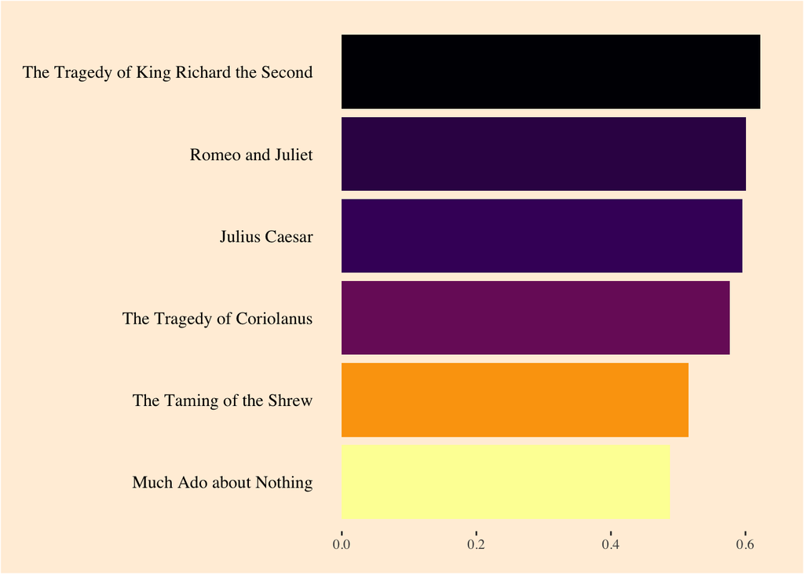

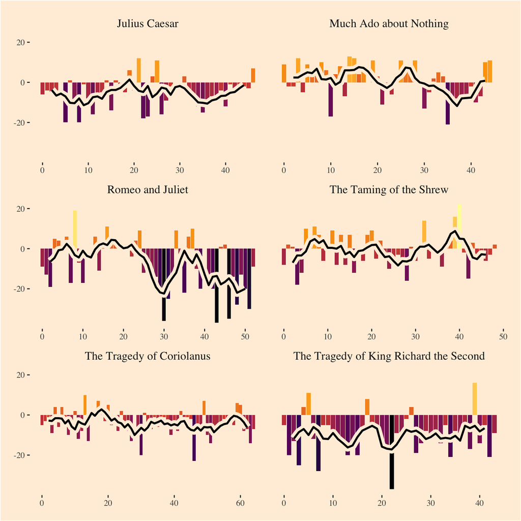

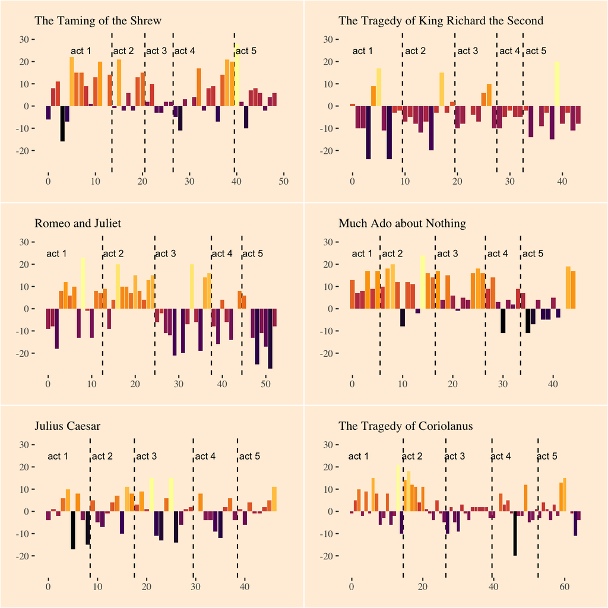

#### Tag for more than 2 emotions

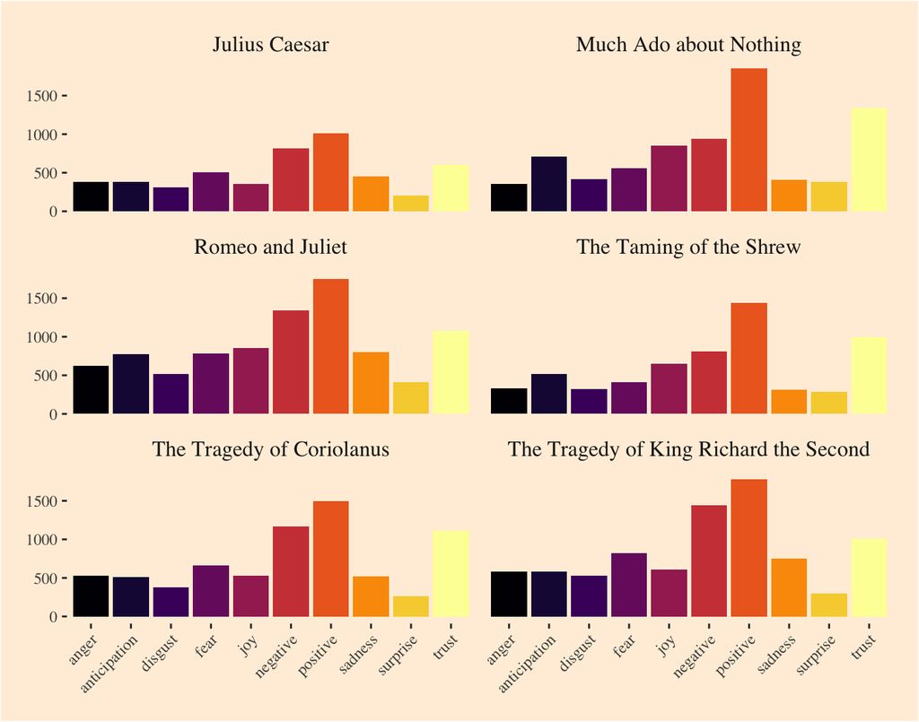

Sentiment analysis: pos, neg, and 8 other sentiment categories.

### Tag for parts of speech

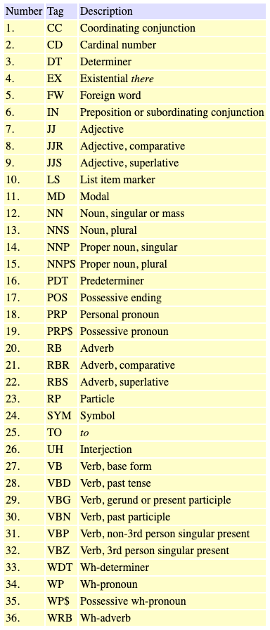

Penn Treebank POS tagset

### Tag for semantic classes

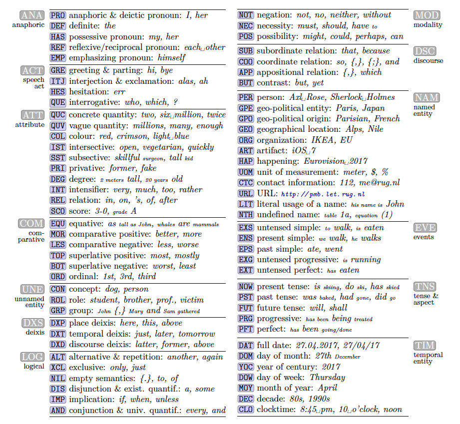

Universal semantic tagset

## Start by loading our data

First we’ll get an inventory of all the .DOCX files in our project directory.

```r
(textfiles <- list.files(pattern = ".docx"))
```

```
[1] "prose and verse csv 500 words.docx"
[2] "Prose and Verse from Shrew.docx"
```

The second file has more formatting and may, for the time being, be more useful. We’ll read it in. Here is the top of its content.

```r
f <- read_docx(textfiles[2])
f %>% head(10)
```

```
 [1] "I am  Christophero  Sly; call not me ' honour ' nor 'lordship.' I"
 [2] "ne'er drank sack in my life; and if you give me any conserves,"
 [3] "give me conserves of beef. Ne'er ask me what raiment I'll wear,"
 [4] "for I have no more doublets than backs, no more stockings than"
 [5] "legs, nor no more shoes than feet- nay, sometime more feet than"
 [6] "shoes, or such shoes as my toes look through the  overleather ."
 [7] "Lord. Heaven cease this idle  humour  in your  honour !"
 [8] "What, would you make me mad? Am not I Christopher Sly, old"
 [9] "Sly's  son of Burton Heath; by birth a  pedlar , by education a"
[10] "cardmaker , by transmutation a bear-herd, and now by present"
```

Here it is, converted to tabular format.

```r
f <-
  f %>%
  enframe() %>%
  select(line = 2) %>%
  mutate(file = textfiles[2])
f %>%
  head(10) %>%
  kbl() %>%
  kable_styling(bootstrap_options = "striped",
                full_width = F,
                position = "left")
```

| line | file |
| --- | --- |
| I am Christophero Sly; call not me ' honour ' nor 'lordship.' I | Prose and Verse from Shrew.docx |
| ne'er drank sack in my life; and if you give me any conserves, | Prose and Verse from Shrew.docx |
| give me conserves of beef. Ne'er ask me what raiment I'll wear, | Prose and Verse from Shrew.docx |
| for I have no more doublets than backs, no more stockings than | Prose and Verse from Shrew.docx |
| legs, nor no more shoes than feet- nay, sometime more feet than | Prose and Verse from Shrew.docx |
| shoes, or such shoes as my toes look through the overleather . | Prose and Verse from Shrew.docx |
| Lord. Heaven cease this idle humour in your honour ! | Prose and Verse from Shrew.docx |
| What, would you make me mad? Am not I Christopher Sly, old | Prose and Verse from Shrew.docx |
| Sly's son of Burton Heath; by birth a pedlar , by education a | Prose and Verse from Shrew.docx |
| cardmaker , by transmutation a bear-herd, and now by present | Prose and Verse from Shrew.docx |

## Narrowing down our interest

I have just received the latest notes from class: the interest seems to be in the difference between verse and prose *crossed with* an interest in character. I interpret this to mean that there are characters that appear both in verse and in prose sections, and we want to know how the language associated with each character differs from verse to prose.

In the text samples I have, character speech is not marked. We might be better off if we pull *Taming of the Shrew* from www.gutenberg.org.

Luckily there is an R module that interfaces with the Gutenberg archives. It is called `gutenbergr`. I will pull the whole text from there.

```r
shakespeare <-
  gutenberg_works(author == "Shakespeare, William")
```

[output not shown]

```r
shakespeare                    %>%
  mutate(entry = row_number()) %>%
  select(entry, title)  %>%
  kbl() %>%
  kable_styling(bootstrap_options = "striped",
                full_width = F,
                position = "left")
```

| entry | title |
| --- | --- |
| 1 | Shakespeare's Sonnets |
| 2 | Venus and Adonis |
| 3 | King Henry VI, First Part |
| 4 | History of King Henry the Sixth, Second Part |
| 5 | The History of King Henry the Sixth, Third Part |
| 6 | The Tragedy of King Richard III |
| 7 | The Comedy of Errors |
| 8 | The Rape of Lucrece |
| 9 | The Tragedy of Titus Andronicus |
| 10 | The Taming of the Shrew |
| 11 | The Two Gentlemen of Verona |
| 12 | Love's Labour's Lost |
| 13 | King John |
| 14 | The Tragedy of King Richard the Second |
| 15 | Romeo and Juliet |
| 16 | A Midsummer Night's Dream |
| 17 | The Merchant of Venice |
| 18 | King Henry IV, the First Part |
| 19 | The Merry Wives of Windsor |
| 20 | King Henry IV, Second Part |
| 21 | Much Ado about Nothing |
| 22 | The Life of King Henry V |
| 23 | Julius Caesar |
| 24 | As You Like It |
| 25 | Hamlet, Prince of Denmark |
| 26 | The Phoenix and the Turtle |
| 27 | Twelfth Night; Or, What You Will |
| 28 | The History of Troilus and Cressida |
| 29 | All's Well That Ends Well |
| 30 | Measure for Measure |
| 31 | Othello, the Moor of Venice |
| 32 | The Tragedy of King Lear |
| 33 | Macbeth |
| 34 | Antony and Cleopatra |
| 35 | The Tragedy of Coriolanus |
| 36 | The Life of Timon of Athens |
| 37 | Pericles, Prince of Tyre |
| 38 | Cymbeline |
| 39 | The Winter's Tale |
| 40 | The Tempest |
| 41 | The Life of Henry the Eighth |
| 42 | A Lover's Complaint |
| 43 | The Passionate Pilgrim |
| 44 | Twelfth Night |
| 45 | Richard II |
| 46 | Henry IV, Part 1 |
| 47 | Henry V |
| 48 | Henry VI, Part 1 |
| 49 | Henry VI, Part 2 |
| 50 | Henry VI, Part 3 |
| 51 | Richard III |
| 52 | Henry VIII |
| 53 | Coriolanus |
| 54 | Titus Andronicus |
| 55 | Timon of Athens |
| 56 | Hamlet |
| 57 | King Lear |
| 58 | Othello |
| 59 | Shakespeare's First Folio |
| 60 | The Tragicall Historie of Hamlet, Prince of Denmarke The First ('Bad') Quarto |
| 61 | The Tragedie of Hamlet, Prince of Denmark A Study with the Text of the Folio of 1623 |
| 62 | Shakespeare's play of the Merchant of Venice Arranged for Representation at the Princess's Theatre, with Historical and Explanatory Notes by Charles Kean, F.S.A. |
| 63 | King Henry the Fifth Arranged for Representation at the Princess's Theatre |
| 64 | The Works of William Shakespeare [Cambridge Edition] [9 vols.] Introduction and Publisher's Advertising |
| 65 | The Tempest The Works of William Shakespeare [Cambridge Edition] [9 vols.] |
| 66 | Two Gentlemen of Verona The Works of William Shakespeare [Cambridge Edition] [9 vols.] |
| 67 | The Merry Wives of Windsor The Works of William Shakespeare [Cambridge Edition] [9 vols.] |
| 68 | Measure for Measure The Works of William Shakespeare [Cambridge Edition] [9 vols.] |
| 69 | The Comedy of Errors The Works of William Shakespeare [Cambridge Edition] [9 vols.] |
| 70 | The New Hudson Shakespeare: Julius Cæsar |
| 71 | The Works of William Shakespeare [Cambridge Edition] [Vol. 2] |
| 72 | Shakespeare's Comedy of The Tempest |
| 73 | The Works of William Shakespeare [Cambridge Edition] [Vol. 7 of 9] |
| 74 | Shakespeare's Tragedy of Romeo and Juliet |
| 75 | The Works of William Shakespeare [Cambridge Edition] [Vol. 6 of 9 vols.] |
| 76 | The Works of William Shakespeare [Cambridge Edition] [Vol. 8 of 9 vols.] |
| 77 | The Works of William Shakespeare [Cambridge Edition] [Vol. 5 of 9] I, II, and III King Henry Sixth; King Richard III; and two other related plays. |
| 78 | The Works of William Shakespeare - Cambridge Edition (4 of 9) (1863) |
| 79 | The Works of William Shakespeare - Cambridge Edition (3 of 9) (1863) |

So our text is there and available, at index no. 10.

```r
IDs <-  shakespeare[c(10),]$gutenberg_id

shakespeare %>%
  filter(gutenberg_id %in% IDs) %>%
  select(gutenberg_id, title)
```

| gutenberg_id | title |
| --- | --- |
| 1508 | The Taming of the Shrew |

Let’s download the play and store it in an R object. I will call it `plays` (plural in case we add more texts or something.)

```r
plays <- gutenberg_download(IDs, meta_fields = "title")
```

```
Determining mirror for Project Gutenberg from http://www.gutenberg.org/robot/harvest
Using mirror http://aleph.gutenberg.org
```